# Data Visualisation

## Applied Data Science

### Outline

- Visualisation: A Psychological Perspective
  - Motivation
  - Theory
- Exploratory Data Analysis
  - EDA Example
  - EDA vs Descriptive Statistics
  - Time Series
- Practical Considerations
  - Technologies
  - Demo

### Why Visualise?

- Making sense of data
- Discovery
- Communication
- Monitoring / Situational awareness
- We can detect information faster than we can move
- Humans are not very good at detecting patterns from numbers

### Gestalt Principles

[figure not shown]

### Preattentive Features

[figure not shown]

- Criteria for evaluation:
  - Which design minimises eye travel?
  - Which design looks best as black and white? (or colourblind)
  - Maximise information to ink ratio
- What to choose when
  - Line graph: to track changes over periods of time
  - Pie Chart: (nearly) never!
  - Divided Rectangle (Waffle): when you are trying to compare parts of a whole
  - Bar Graph: to compare things between different groups
  - Histogram: to track changes over time, or probability distributions. Note withhistograms, the width is significant, as well as the height, unlike a bar graph

[figure not shown]

- Which group has the highest/lowest rates? When?
- Which group has an increasing/decreasing temporal trend?
- Which group has a faster/slower rate of change?

[figure not shown]

### Exploratory Data Analysis (EDA)

[figure not shown]

### Primary Analysis

[figure not shown]

Figure: Histogram of tip amounts where the bins cover £1 increments. The distribution of values is skewed right and unimodal, as is common in distributions of small, non-negative quantities.

[figure not shown]

Figure: Histogram of tip amounts where the bins cover £0.10 increments. An interesting phenomenon is visible: peaks occur at the whole-dollar and half-dollar amounts, which is caused by customers picking round numbers as tips. This behaviour is common to other types of purchases too.

[figure not shown]

Figure: Scatterplot of tips vs. bill. Points below the line correspond to tips that are lower than expected (for that bill amount), and points above the line are higher than expected. We might expect to see a tight, positive linear association, but instead variation increases with tip amount. In particular, there are more points far away from the line in the lower right than in the upper left, indicating that more customers are very cheap than very generous.

[figure not shown]

Figure: Tips vs. bill separated by gender and smoking section. Smoking parties have a lot more variability in the tips that they give. Males tend to pay the (few) higher bills, and the female non-smokers tend to be very consistent tippers (with three conspicuous exceptions shown in the sample).

### EDA Outcomes

- What is learnt from the plots is different from what is illustrated by the regression model, even though the experiment was not designed to investigate any of these other trends?
- Suggests hypotheses about tipping that may not have been anticipated in advance
- Could lead to interesting follow-up experiments where the hypotheses are formally stated and tested by collecting new data

### EDA virtuous circle

[figure not shown]

### Anscombe’s quartet

[figure not shown]

### Anscombe’s quartet

[figure not shown]

- Descriptive statistics can hide important information!

### Counter examples

[figure not shown]

http://www.tylervigen.com/spurious-correlations

### Counter examples

[figure not shown]

### Time Series Visualisation

- Data
  - Frame of Reference
    - Abstract
    - Spatial
  - Number of Variables
    - Univariate
    - Multivariate
- Time
  - Arrangement
    - Linear
    - Cyclic
  - Time Primitives
    - Instant
    - Interval
- Visualisation
  - Mapping
    - Static
    - Dynamic
  - Dimensionality
    - 2D
    - 3D

[figure not shown]

### Visualisation

- Language built-ins
  - R, Matlab, Octave, Mathematica ...
- OS-based
  - gnuplot
- Commerical tools
  - Tableau; Microsoft BI
- python
  - Matplotlib; Seaborn; ggplot; bokeh
- JavaScript
  - D3.js; DC.js; NVD3; Vega HighCharts/HighStock/HighMaps; plotly.js; Leaflet; MetricsGraphics.js

### Supporting Techonology

- Pandas
- Flask
- Shapely
- Crossfilter
- Underscore.js
- Keen Dashboards

### Python

- pandas: handy for simple plots; need to learn matplotlib to customize
- seaborn: supports some more complex visualisation approaches but still requires matplotlib knowledge to tweak. Colour schemes are a nice bonus.
- ggplot is a plotting system for Python based on R’s ggplot2 and the Grammar of Graphics (Wilkinson, 2012)
- bokeh is a robust tool if you want to set up your own visualisation server but may be overkill for the simple scenarios
- plotly generates the most interactive graphs. You can save them offline and create very rich web-based visualisations ... but commercial license

### Demo

#### Import the data

See http://pbpython.com/web-scraping-mn-budget.html

```python
import pandas as pd
import matplotlib.pyplot as plt

%matplotlib inline
```

Some the libaries that are needed to start reading in the data and to be able to create some basic graphs.

```python
df = pd.read_csv("mn-budget-detail-2014.csv")
df = df.sort_values('amount', ascending=False)
df.head()
```

|  | category | detail | amount |
| --- | --- | --- | --- |
| 46 | ADMINISTRATION | Capitol Renovation and Restoration Continued | 126300000 |
| 1 | UNIVERSITY OF MINNESOTA | Minneapolis; Tate Laboratory Renovation | 56700000 |
| 78 | HUMAN SERVICES | Minnesota Security Hospital - St. Peter | 56317000 |
| 0 | UNIVERSITY OF MINNESOTA | Higher Education Asset Preservation (HEAPR) 1 | 42500000 |
| 5 | MINNESOTA STATE COLLEGES AND UNIVERSITIES | Higher Education Asset Preservation (HEAPR) 2 | 42500000 |

### Basic plotting with pandas/matplotlib

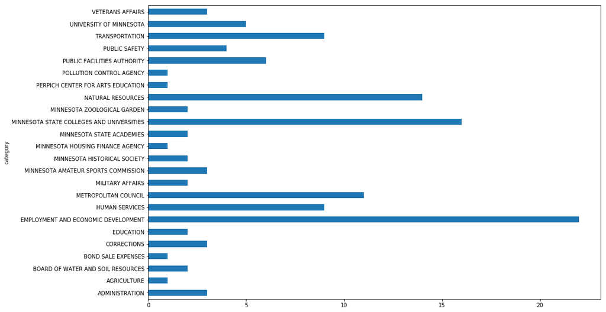

```python
sizes = df.groupby('category').size()
sizes.plot(kind='barh', figsize=(15,10))
```

### Nicer styling with seaborn

```python
import seaborn as sns
sns.set_style('white')
```

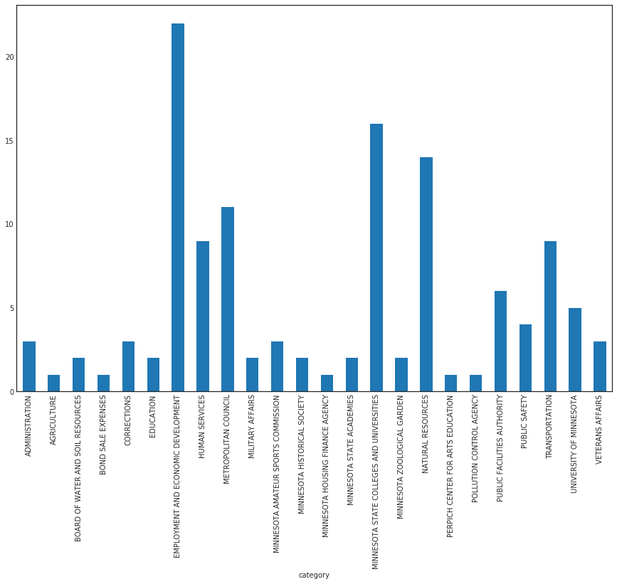

```python
sizes.plot(kind='bar', figsize=(15,10))
```

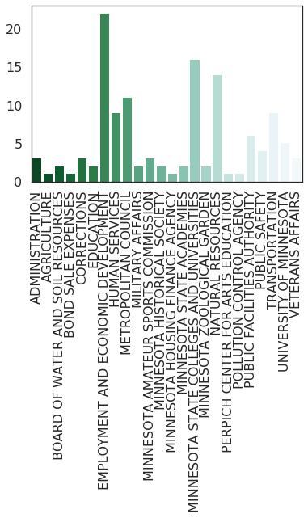

```python
sns.set_context('poster')
bar_plot = sns.barplot(x=sizes.index.values, y=sizes.values, palette="BuGn_r", order=sizes.index.values.tolist())
plt.xticks(rotation=90)
```

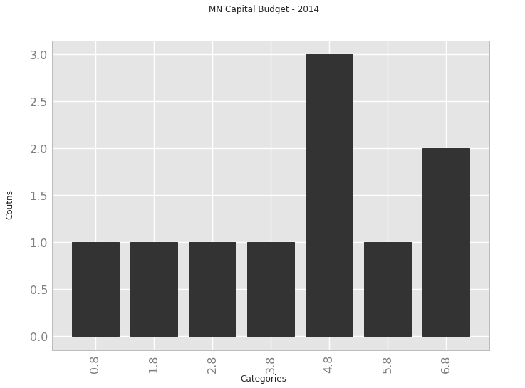

```python
dfs = df.sort_values('amount',ascending=False)[:10]

p = ggplot(dfs, aes(x="category",y="amount")) + \
    geom_bar(stat="bar", labels=dfs["category"].tolist()) +\
    ggtitle("MN Capital Budget - 2014") + \
    xlab("Categories") +  \
    ylab("Coutns") + scale_y_continuous(labels='millions') + \
    theme(axis_text_x=element_text(angle=90))
print p
```

### Bokeh

```python
bar = Bar(sizes, filename="bar.html", title="MN Capital Budget - 2014", legend=False)
show(bar)
```

### pygal

```python
bar_chart = pygal.Bar(style=LightStyle, width=800, height=600,
                      legend_at_bottom=True, human_readable=True,
                      title='MN Capital Budget - 2014')
```

```python
for index, row in sizes.iteritems():
    bar_chart.add(index, row)
```

```python
bar_chart.render_in_browser()
```

```
file:///tmp/tmptNkPDa.html
```